# Pretest HUPS

Chris Harris

Last edited: 10 mei, 2019

## Frequency

*Which of these two people did you encounter more often?*

[image left] [image right]

Most people correctly identify which person was shown more frequently. Only on three instances did participants get this wrong:

```r
freq_long %>%
  filter(freq == 0) %>%
  knitr::kable(caption = "Instances in which frequency is wrong", digits = 2) %>%
  kable_styling(bootstrap_options = "hover", full_width = F, position = "center")
```

Instances in which frequency is wrong

| participant.id | cond | freq |
| --- | --- | --- |
| 5c74edf1280f66001ad7ca29 | rich | 0 |
| 5c3a4daa6c4e3d0001b89af8 | rich | 0 |
| 58add914ef58a9000119d98c | imp | 0 |

Here the percentage scores of correct instances per condition:

```r
freq_long %>%
  group_by(cond) %>%
  summarize(avg = mean(freq)) %>%
  knitr::kable(caption = "Instances correctly identified", digits = 2) %>%
  kable_styling(bootstrap_options = "hover", full_width = F, position = "center")
```

Instances correctly identified

| cond | avg |
| --- | --- |
| rich | 0.96 |
| imp | 0.98 |

These do not differ from one another:

```r
distr <- table(freq_long$cond, freq_long$freq)

testBF <- proportionBF(y = distr["rich", "1"],
             N = distr["rich", "1"] + distr["rich", "0"],
             p = distr["imp", "1"] / (distr["imp", "1"] + distr["imp", "0"]),
             rscale = "ultrawide",
             nullInterval = c(0, 1)) %>%
  printBFb(print = TRUE)
testFR <- binom.test(x = distr["rich", "1"],
           n = distr["rich", "1"] + distr["rich", "0"],
           p = distr["imp", "1"] / (distr["imp", "1"] + distr["imp", "0"]),
           alternative = "two.sided")

paste0(testBF, ", *p* = ", printnum(testFR$p.value))
```

[1] “*BF<sub>01</sub>* = 1.71, *p* = 0.26”

## Preference

*Which of these two people seemed happier to you?*

[image left] [image right]

Preference was coded as -1 or +1 with the frequent option always being +1.  
There was a general preference for the *frequent* option as seen here:

```r
pref_long %>%
  group_by(cond) %>%
  summarize(avg = mean(pref)) %>%
  knitr::kable(caption = "Average preference", digits = 2) %>%
  kable_styling(bootstrap_options = "hover", full_width = F, position = "center")
```

Average preference

| cond | avg |
| --- | --- |
| rich | 0.18 |
| imp | 0.14 |

These, surprisingly, do not differ from one another:

```r
distr <- table(pref_long$cond, pref_long$pref)

testBF <- proportionBF(y = distr["rich", "1"],
                       N = distr["rich", "1"] + distr["rich", "-1"],
                       p = distr["imp", "1"] / (distr["imp", "1"] + distr["imp", "-1"]),
                       rscale = "ultrawide",
                       nullInterval = c(0, 1)) %>%
  printBFb(print = TRUE)
testFR <- binom.test(x = distr["rich", "1"],
                     n = distr["rich", "1"] + distr["rich", "-1"],
                     p = distr["imp", "1"] / (distr["imp", "1"] + distr["imp", "-1"]),
                     alternative = "two.sided")

paste0(testBF, ", *p* = ", printnum(testFR$p.value))
```

[1] “*BF<sub>01</sub>* = 5.48, *p* = 0.89”

But also do not differ meaningfully from 0:

```r
distr <- table(pref_long$pref)

testBF <- proportionBF(y = distr["1"],
                       N = distr["1"] + distr["-1"],
                       p = .5,
                       rscale = "ultrawide",
                       nullInterval = c(.5, 1)) %>%
  printBFb(print = TRUE)
testFR <- binom.test(x = distr["1"],
                     n = distr["1"] + distr["-1"],
                     p = .5,
                     alternative = "greater")

paste0(testBF, ", *p* = ", printnum(testFR$p.value))
```

[1] “*BF<sub>+0</sub>* = 0.81, *p* = 0.07”

## Conditional estimates

*On average, did this person smile or frown more often?*

Left : Frown |———-| Smile  
Right: Frown |———-| Smile

Here (scale: 0 - 100) are the conditional estimates participants made:

```r
cond_long %>%
  group_by(cond, frequency) %>%
  summarize(avg = mean(value)) %>%
  knitr::kable(caption = "Conditional estimates", digits = 2) %>%
  kable_styling(bootstrap_options = "hover", full_width = F, position = "center")
```

Conditional estimates

| cond | frequency | avg |
| --- | --- | --- |
| rich | freq | 62.20 |
| rich | infr | 56.22 |
| imp | freq | 45.57 |
| imp | infr | 37.76 |

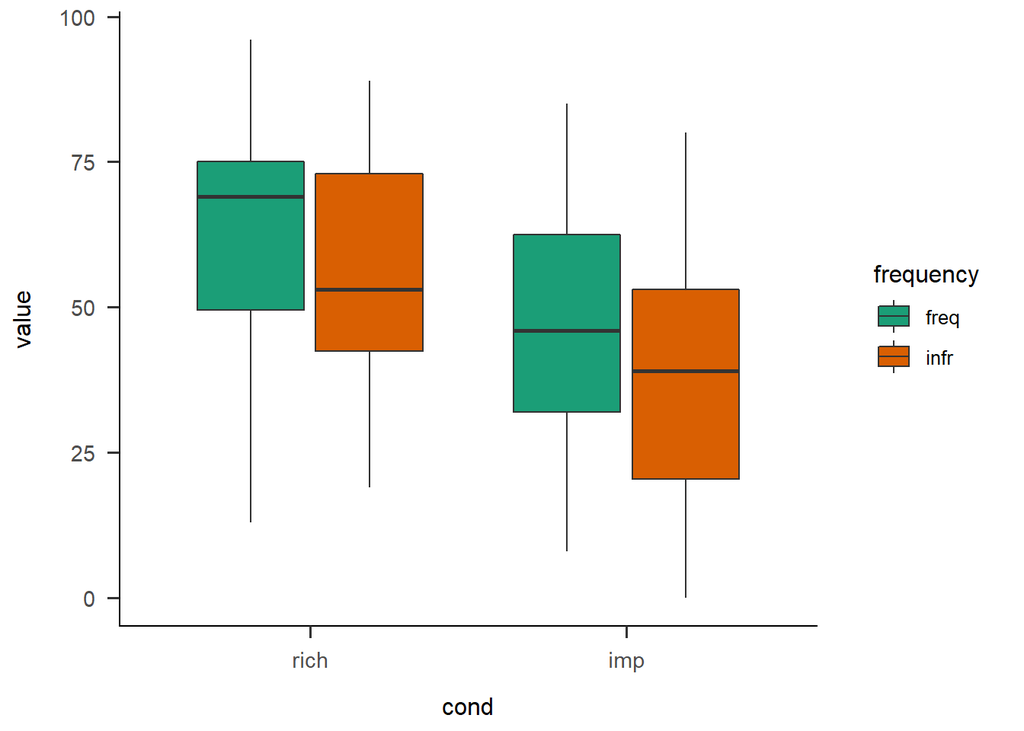

```r
cond_long %>%
  ggplot(aes(x = cond,
             y = value,
             fill = frequency)) +
  geom_boxplot() +
  scale_fill_brewer(palette = "Dark2") +
  theme_apa()
```

These estimates result in the following Δp-scores:

```r
df1 %>%
  mutate(rich = (cond_rich_fr - cond_rich_in) / 100,
         imp  = (cond_imp_fr - cond_imp_in) / 100) %>%
  summarize(rich = mean(rich),
            imp  = mean(imp)) %>%
  knitr::kable(caption = "dp-scores", digits = 2) %>%
  kable_styling(bootstrap_options = "hover", full_width = F, position = "center")
```

dp-scores

| rich | imp |
| --- | --- |
| 0.06 | 0.08 |

The two conditions do not differ from one another:

```r
df1 %>%
  mutate(rich_dp = (cond_rich_fr - cond_rich_in) / 100,
         imp_dp  = (cond_imp_fr - cond_imp_in) / 100) %$%
  ttestBF(x = rich_dp,
          y = imp_dp,
          nullInterval = c(-Inf, Inf),
          paired = TRUE) %>%
  printBFt(print = TRUE)
```

[1] “*BF<sub>01</sub>* = 6.25, *d* = -0.04, *95% HDI* [-0.31, 0.22]”

This is surprising, as we would have expected smiling to be associated with the frequent person in the reward-rich condition, but with the infrequent person in the reward-impoverished condition.

There is an overall difference from 0:

```r
df1 %>%
  mutate(rich_dp = (cond_rich_fr - cond_rich_in) / 100,
         imp_dp  = (cond_imp_fr - cond_imp_in) / 100) %>%
  select(rich_dp, imp_dp) %>%
  gather(key = "cond",
         value = "dp") %$%
  ttestBF(dp,
          mu = 0,
          nullInterval = c(0, Inf)) %>%
  printBFt(print = TRUE)
```

[1] “*BF<sub>+0</sub>* = 2.22, *d* = 0.21, *95% HDI* [0.03, 0.41]”

## Demographic data

Our participants:

```r
# Summary of most relevant demographic data
df1 %>%
  summarise(N = n(),
            female = length(which(gender == "female")),
            age_mean = mean(age, na.rm = TRUE),
            age_sd = sd(age, na.rm = TRUE),
            Psychstudents_percent = length(which(psych == "Yes")) / n() * 100) %>%
  knitr::kable(caption = "Demographic data", digits = 2) %>%
  kable_styling(bootstrap_options = "hover", full_width = F, position = "center")
```

Demographic data

| N | female | age_mean | age_sd | Psychstudents_percent |
| --- | --- | --- | --- | --- |
| 51 | 25 | 29.65 | 10.37 | 7.84 |

And their level of education:

```r
# Level of education
df1 %>%
  group_by(edu) %>%
  summarise(count = length(edu)) %>%
  knitr::kable(caption = "Level of education", digits = 2) %>%
  kable_styling(bootstrap_options = "hover", full_width = F, position = "center")
```

Level of education

| edu | count |
| --- | --- |
| No formal education | 1 |
| Secondary school/GCSE | 1 |
| College/A levels | 15 |
| Undergraduate degree (BA, BSc or comparable) | 16 |
| Graduate degree (MA, MSc or comparable) | 14 |
| Doctorate degree (PhD, MD, or comparable) | 4 |

## Counterbalancing

In this preliminary analyses I ignore gender (do we first show men or first show women), as well as which male/female individual is shown frequently and which is shown infrequently.

The logic is as follows:

- Make the frequently shown face always the +1 (right) option
- Link with condition

And for the conditional estimates:

- Determine frequently and infrequently shown option
- Link with condition

```r
df %>%
    # Ignore Order-Women and Order-Men. There should be no difference
    #  2(condition: rich-imp vs. imp-rich, within)
    # x2(primacy: left-right vs. right-left frequent)
    # Preference
    # 1: Frequent = 1, infrequent = -1
    mutate(pref1_raw2 = ifelse(primacy == "left frequent", pref1_raw * (-1), pref1_raw),
           freq1_raw2 = ifelse(primacy == "left frequent", freq1_raw * (-1), freq1_raw),

           pref2_raw2 = ifelse(primacy == "left frequent", pref2_raw,        pref2_raw * (-1)),
           freq2_raw2 = ifelse(primacy == "left frequent", freq2_raw,        freq2_raw * (-1))) %>%
    # 2: assign condition
    mutate(pref_rich = ifelse(condition == "rich", pref1_raw2, pref2_raw2),
           pref_imp  = ifelse(condition == "rich", pref2_raw2, pref1_raw2),

           freq_rich = ifelse(condition == "rich", freq1_raw2, freq2_raw2),
           freq_imp  = ifelse(condition == "rich", freq2_raw2, freq1_raw2)) %>%
    # Conditionals
    # 1: frequently vs. infrequently shown
    mutate(cond_first_freq = ifelse(primacy == "left frequent", cond1_raw, cond2_raw),
           cond_first_infr = ifelse(primacy == "left frequent", cond2_raw, cond1_raw),

           cond_secon_freq = ifelse(primacy == "left frequent", cond4_raw, cond3_raw),
           cond_secon_infr = ifelse(primacy == "left frequent", cond3_raw, cond4_raw)) %>%
    # 2: assign condition
    mutate(cond_rich_fr = ifelse(condition == "rich", cond_first_freq, cond_secon_freq),
           cond_rich_in = ifelse(condition == "rich", cond_first_infr, cond_secon_infr),

           cond_imp_fr  = ifelse(condition == "rich", cond_secon_freq, cond_first_freq),
           cond_imp_in  = ifelse(condition == "rich", cond_secon_infr, cond_first_infr))
```